# Patterns of Contraceptive Use in Haiti

Ilana Barach

July 2025

### Demographics

Figure 1. Demographic Characteristics of Respondents

| **Variable** | **N = 15,513**<sup>1</sup> |
| --- | --- |
| wealth index combined |  |
| poorest | 3,104 (20%) |
| poorer | 3,168 (20%) |
| middle | 3,081 (20%) |
| richer | 3,165 (20%) |
| richest | 2,995 (19%) |
| educational attainment |  |
| no education | 2,789 (18%) |
| incomplete primary | 3,552 (23%) |
| complete primary | 1,364 (8.8%) |
| incomplete secondary | 6,434 (41%) |
| complete secondary | 512 (3.3%) |
| higher | 862 (5.6%) |
| type of place of residence |  |
| urban | 6,087 (39%) |
| rural | 9,426 (61%) |

<sup>1</sup> n (%)

### **Prevalence of Contraceptives**

Of the respondents who had contraceptive data, only 24% were currently using contraceptives. 52 percent had never used contraceptives, and 24% had used them before their last birth. Interestingly, nobody was newly on contraceptives since their last birth. The percentage of respondents using contraceptives was roughly the same for all levels of wealth and education.

### What Contraceptive Methods are being used?

Figure 2 shows the prevalence of contraceptive methods of respondents who reported using contraceptives. The most common method reported at the time of the survey was injection (52%). Male condom—used by about a quarter of respondents—was the next most common method. The remaining methods were used by a low percentage of respondents. For example, implants and pills were each used by only six percent of respondents. Another notable pattern is that seven percent of contraceptive users reported relying on periodic abstinence or withdrawal, which are known to have a higher risk of failure if not used correctly. Choice of contraceptive methods is influenced by factors such as access to healthcare, medical staff knowledge, availability of method, and social views.

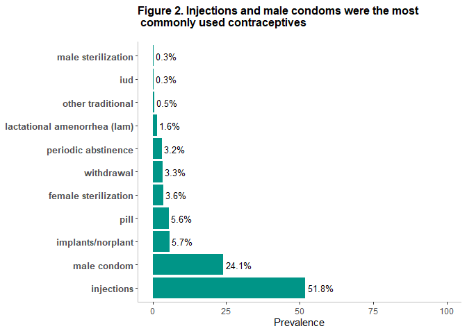

### Contraceptive Method and Age:

There were some age differences in choice of contraceptive. Respondents who used implants, pills, or injections had an older median age compared to respondents using male condoms. Figure 3 is a boxplot showing the spread of respondent age by contraceptive type for respondents who used the four most common methods. The most popular method for respondents 20 years or younger was male condom. Few respondents under the age of 25 reported using implants or pills. While respondents using injections had a higher median age than those using male condoms, Figure 3 shows that injections were popular for a wide age-range, including down to about 18 years-old. Male condoms are the only one of these four methods that can be accessed without a healthcare provider. It is possible that younger women experience more barriers to family planning. For example, Masonbrink et al. (2023) examined contraception use in Haiti and found that 42% of females aged 14-24 reported concern about parental approval of birth control use. Additionally, about one-third reported feeling uncomfortable asking for birth control at a clinic. Contraceptive access is complex, and there are likely other factors at play as well.

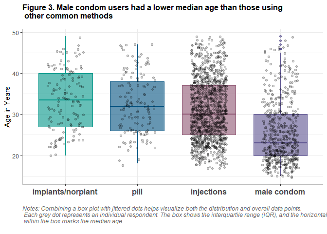

### Contraceptive Method and Wealth

Figure 4 shows that the use of male condoms grew with increased wealth. About two thirds of poorest/poorer respondents reported using injections, and only 9 to 10 percent used male condoms. The prevalence of male condoms grew substantially to 34 percent in the richer respondents and 45 percent in the richest respondents. Note that the bars in each wealth group will not add up to 100 percent because a small proportion of respondents used methods that are not shown.

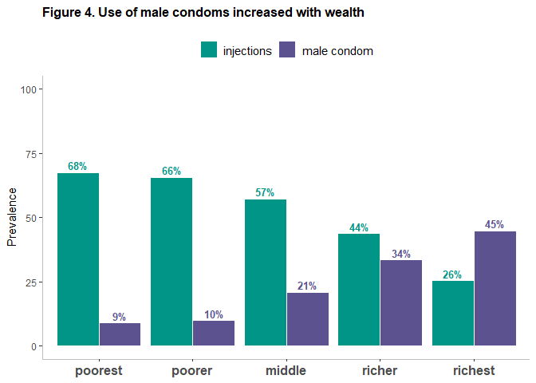

### Last Source of Contraceptives

By far, the most common source of respondents’ contraceptives was government clinic/pharmacy (See Figure 5). NGO was the next most commonly used source (17%). Private clinic/delivery, pharmacy, and shop, church, or friend were each only used by a small proportion of respondents.

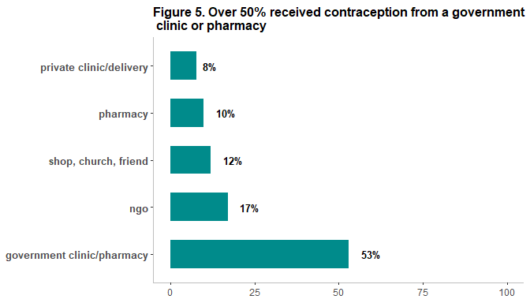

### Last Source of Contraceptives and Wealth

Government clinic/pharmacy was the most common source of contraceptives in all wealth groups (See Figure 6). However, while most respondents in the poorest, poorer, and middle wealth groups sourced their contraceptives at government clinics/pharmacies, less than half did so in the richer/richest categories. The percentage of respondents sourcing their contraceptives at an NGO also decreased as wealth increased, with about a quarter of poorer/poorest respondents doing so.

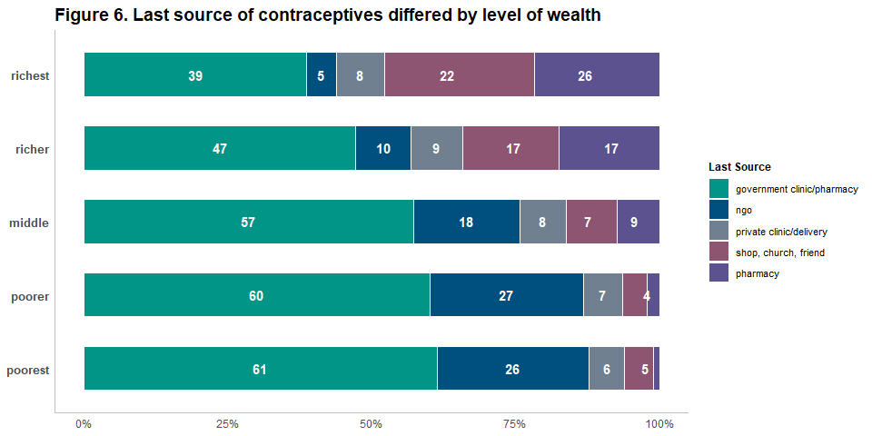

#### References

Masonbrink, A.R., Hurley, E.A., Schuetz, N. *et al.* Sexual behaviors, contraception use and barriers among adolescents and young adults in rural Haiti. *BMC Women’s Health* **23**, 137 (2023). https://doi.org/10.1186/s12905-023-02268-5